# Poop Analysis

- Show All Code
- Hide All Code
- View Source

Author

Daniel Bagley

Published

January 5, 2026

## Introduction

When I was a child, I was introduced to the classic children’s book *Everyone Poops* by Taro Gomi. As you might imagine, the primary message of this book is that all creatures defecate; presumably this book is intended for young children learning to potty in a toilet instead of a diaper. Despite not learning about the title until many years after I had mastered bladder control, this book does raise one interesting question for adults as well as children: **If everyone poops, how much do they poop?**

It was with this question in mind that I began inquiring of others (friends, family, and strangers have all been asked) to collect anectodal data regarding standard human pooping habits. As a result of these inquiries, I began to suspect that I poop more often than my coworkers and family members. Therefore, I determined that a quantitative study was required and, for the entirety of 2025, recorded each time I defecated. This analysis will attempt to determine the essential characteristics of my personal pooping habits. Data was recorded after each bowel movement on a physical whiteboard and in an online spreadsheet (Google Sheet) to provide two sources of data. The two sources were harmonized after each week and the whiteboard erased. This allowed for error-checking which proved necessary on Jan 20 and September 1, both of which had 3 whiteboard-indicated poops but only 2 on the spreadsheet.

```r
pacman::p_load(tidyverse, googlesheets4,
               ggthemes,latex2exp)

url <- "https://docs.google.com/spreadsheets/d/1-4ZyW7nfctkvv_q9eDDJivb3zpi1Wey6b1ORxDq8-G0/edit?gid=0#gid=0"

poop <-read_sheet(url, col_types = "cic") |>
  mutate(date = parse_date_time(date, orders = "m/d/Y"),
         poop_cum_sum = cumsum(poops),
         poop_pareto = poop_cum_sum / sum(poops),
         idx = 1:length(poops),
         poop_month = month(date),
         day_of_month = mday(date)) |>
  filter(date < parse_date_time("2026-01-01", orders = "Y-m-d")) #ignore data outside of 2025

first_of_month <- poop |>
  mutate(day_year = yday(date)) |>
  filter(day_of_month == 1)


total_poops <- sum(poop$poops)

month_breaks <- first_of_month$day_year

five_poop <- poop |>
  filter(poops == 5)

around_five <- five_poop |>
  mutate(plus_3 = idx + 3,
         plus_2 = idx + 2,
         plus_1 = idx + 1,
         minus_3 = idx - 3,
         minus_2 = idx - 2,
         minus_1 = idx - 1,
         incident = 1:n()) |>
  pivot_longer(cols = c("plus_3", "plus_2", "plus_1",
                        "idx",
                        "minus_1", "minus_2", "minus_3"), values_to = "index") |>
  select(pattern_group = name, idx = index, incident) |>
  left_join(poop, by = "idx") |>
  mutate(pattern_index = case_when(pattern_group == "minus_3" ~ -3,
                                   pattern_group == "minus_2" ~ -2,
                                   pattern_group == "minus_1" ~ -1,
                                   pattern_group == "idx" ~ 0,
                                   pattern_group == "plus_1" ~ 1,
                                   pattern_group == "plus_2" ~ 2,
                                   pattern_group == "plus_3" ~ 3))
```

## Visualizing the Year’s Poops

We will first examine a plot of all poops over the year to see if any obvious patterns emerge. While it may be the case that early poop-tracking (Jan and Feb esp.) was somewhat error-prone due to under-reporting when pooping in an unfamiliar location where the tracking board whas unavailable, it is still odd to note that of only 5 days throughout the year wherein 5 poops were recorded, 3 of those days occurred in the last 2 months of the year. Also note that despite 22 days of 1 poop only, there are no recorded 0-poop days.

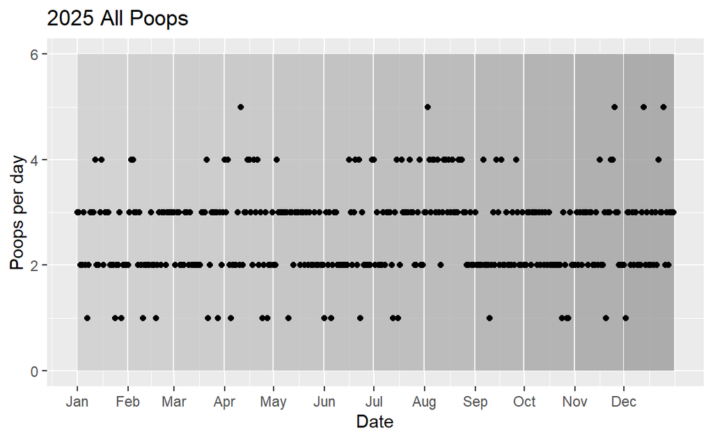

```r
poop |>
  ggplot(aes(y = poops, x = idx)) +
    geom_area(aes(y = 6, fill = factor(poop_month)), alpha = .77) +
    geom_point() +
    labs(title = "2025 All Poops",
       y = "Poops per day",
       x = "Date") +
    scale_fill_grey(start = 0.8, end = 0.6) +
    scale_x_continuous(breaks = month_breaks,
                       labels = c("Jan", "Feb", "Mar",
                                  "Apr", "May", "Jun",
                                  "Jul", "Aug", "Sep",
                                  "Oct", "Nov", "Dec")) +
    theme(legend.position = "none")
```

For a simpler presentation of the number of poops per day irrespective of date, consider this table:

```r
mosaic::favstats(poops ~ tracker, data = poop) |>
  select(Poops = mean, n = n) |> pander::pander(caption = "Poops Per Day")
```

Poops Per Day

| Poops | n |
| --- | --- |
| 1 | 22 |
| 2 | 155 |
| 3 | 143 |
| 4 | 40 |
| 5 | 5 |

Note that 2 poops was most common, while 3 poops was nearly as common. 4, 1 and 5 in that order were much less common. Let us examine another summary of the poops per day:

```r
per_day_fav <- mosaic::favstats(poop$poops)[-9] #remove "missing" because no values are missing
per_day_fav |> pander::pander()
```

| min | Q1 | median | Q3 | max | mean | sd | n |
| --- | --- | --- | --- | --- | --- | --- | --- |
| 1 | 2 | 3 | 3 | 5 | 2.592 | 0.8157 | 365 |

With an average of 2.59, it seems that an emperical distribution of poops per day is centered around 2 and 3, with a slight right skew.

## The 1000-Poop Year

Based on the total number of poops throughout the year and the human tendency to prefer “nice, round numbers”, we will compare the actual year-total poops to a theoretical 1000-poop year to determine how close to 1000 poops I came and whether it is possible I may achieve that number of poops in a subsequent year. Let us visualize the cumulative poop total over the year in comparison to a projected poop slope which would lead to accumulating 1000 total poops for the year:

### Poop Pareto

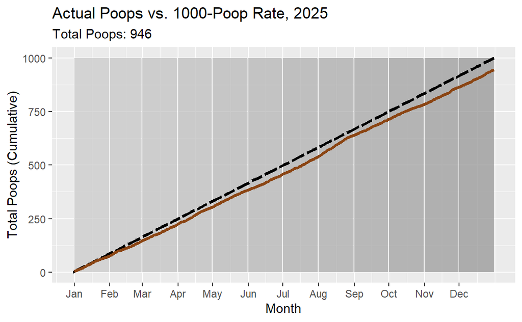

```r
poop |>
  ggplot(aes(y = poop_cum_sum, x = idx)) +
    geom_area(aes(y = 1000, fill = factor(poop_month)), alpha = .77) +
    stat_function(fun = function(x) (1000 / 365) * x,
                  linetype = "5141", linewidth = 1.2, xlim = c(0,365)) +
    geom_line(color = "saddlebrown", linewidth = 1.2) +

    labs(title = "Actual Poops vs. 1000-Poop Rate, 2025",
         subtitle = "Total Poops: 946",
         y = "Total Poops (Cumulative)",
         x = "Month") +
    scale_fill_grey(start = 0.8, end = 0.6) +
    scale_x_continuous(breaks = month_breaks,
                       labels = c("Jan", "Feb", "Mar",
                                  "Apr", "May", "Jun",
                                  "Jul", "Aug", "Sep",
                                  "Oct", "Nov", "Dec")) +
    theme(legend.position = "none")
```

Though using a cumulative sum obviously violates the assumption of independence, the slope of a poop-per-day linear regression is still useful information (the variance of the model will be highly underestimated due to the autocorrelated nature of a cumulative sum).

To determine if a 1000-Poop year is statistically likely given the observed value of 946, we will analyze the required poops per day $\frac{1000}{365} \approx 2.74$ against the sample of 365 observed daily poops:

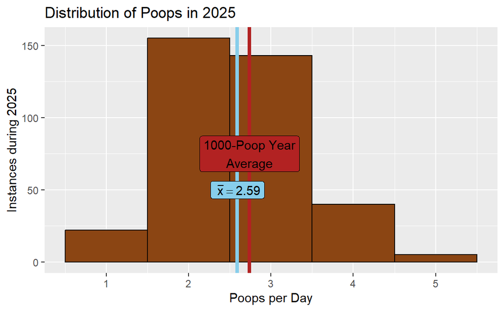

```r
poop_mean <- mean(poop$poops)

mean_label <-TeX(r"( $\bar{x} = 2.59$)")

ggplot(poop, aes(x = poops)) +
  geom_histogram(fill = "saddlebrown", color = "black", binwidth = 1) +
  labs(title = "Distribution of Poops in 2025",
       x = "Poops per Day",
       y = "Instances during 2025") +
  geom_vline(xintercept = poop_mean, color = "skyblue", linewidth = 1.5) +
  geom_vline(xintercept = (1000/365), color = "firebrick", linewidth = 1.5) +
  annotate(geom = "label", x = poop_mean, y = 50,
           label = mean_label, text.color = "black", fill = "skyblue") +
  annotate(geom = "label", x = (1000/365), y = 75,
           label = "1000-Poop Year\nAverage", text.color = "black", fill = "firebrick")
```

From the visualization, it seems that the sample mean poops per day is not far from the required poops per day to achieve the 1000-Poop year. A t-test will further elucidate. We set level of significance $\alpha = 0.05$ and due to large sample size assume the Central Limit Theorem applies to this sample. We may now proceed with a t-Test:

### 1000-Poop Year Average Poops Per Day 1-Sample t-Test

```r
t.test(poop$poops, mu = 1000/365) |>
  pander::pander()
```

One Sample t-test: `poop$poops`

| Test statistic | df | P value | Alternative hypothesis | mean of x |
| --- | --- | --- | --- | --- |
| -3.465 | 364 | 0.000593 * * * | two.sided | 2.592 |

While the two values seem rather close together, given the large sample size and small variance of the sample, we must conclude that if my current pooping habits do not change drastically (ie, 3- and 4-poop days become more common than 2-poop days), I am unlikely to achieve a 1000-Poop year.

## Five Poop Days

As a last matter of curiosity, it is intriguing that of all 365 days in the year, only 5 featured a 5-poop day. Perhaps these seminal defecation events provide an interesting pattern. Here is a visual of the 5-poop days’ surrounding data:

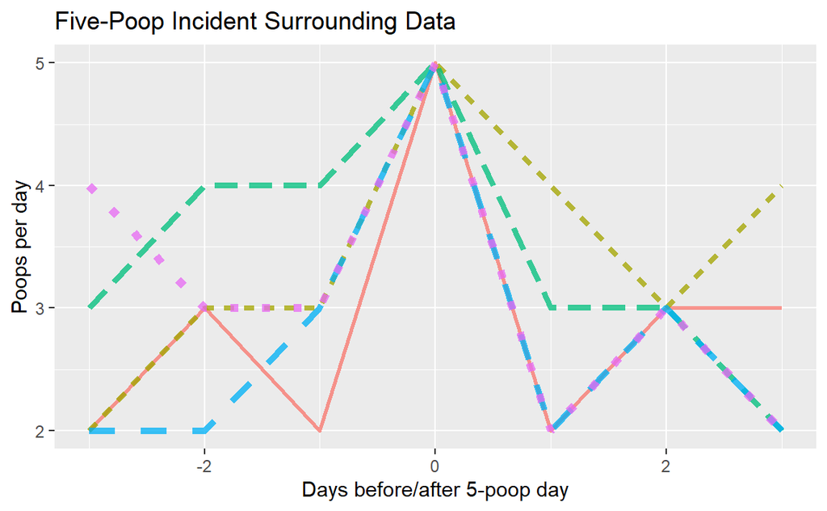

```r
ggplot(around_five, aes(x = pattern_index, y = poops,
                        linewidth = incident, linetype = factor(incident),
                        color = factor(incident))) +
  geom_line(alpha = 0.77) +
  labs(title = "Five-Poop Incident Surrounding Data",
       x = "Days before/after 5-poop day",
       y = "Poops per day") +
  scale_linewidth_continuous(range = c(1,2)) +
  theme(legend.position = "none")
```

While a naive analysis might predict that poop-per-day values surrounding 5-poop days would be lower than the average (1- or even 0-poop days before/after a 5-poop day), this is not observed in the data.

## Conclusion

While 2025’s Defecation research initiative yielded interesting results, there is still much to plumb in the study of Poops-per-day. Further research may seek to further quantify pooping trends by availing the researcher of before/after weigh-ins and qualitative assessments of size as well as ratings according to the Bristol Stool Chart. However, the primary goal of this analysis, to determine a baseline of my pooping habits, has been a success. While a 1000-Poop year is not likely at current defecatory rates, an increase in the consumption of natural laxatives (prunes and blueberries have been suggested) may facilitate that goal.